# Projeto Metodos

Juan Almeida, Catarina Silva, Diana Marcela

11 de outubro de 2016

## Introdução do problema

O ganho de um transistor consiste na diferença entre o emissor e o coletor. A variável Ganho (em hFE) pode ser controlada no processo de deposição de íons por meio das variáveis Tempo de emissão (em minutos) e Dose de íons (x10^{14}). [Dados](https://docs.google.com/spreadsheets/d/1OQ8Ukklrm8pV4WCu7RrhUuJ59XTYnLVoV6bfePCpl9M/edit?usp=sharing)

```r
amostra <- read.csv("dados.csv")
amostra
```

```
##    x1.tempo y.ganho x2.dose
## 1       195    1004    4.00
## 2       255    1636    4.00
## 3       195     852    4.60
## 4       255    1506    4.60
## 5       225    1272    4.20
## 6       225    1270    4.10
## 7       225    1269    4.60
## 8       195     903    4.30
## 9       255    1555    4.30
## 10      225    1260    4.00
## 11      225    1146    4.70
## 12      225    1276    4.30
## 13      225    1225    4.72
## 14      230    1321    4.30
```

## Problema A

Apresente gráficos de dispersão para as variáveis X1 versus Y e X2 versus Y . Há alguma suspeita de relação linear entre as variáveis independentes e dependente?

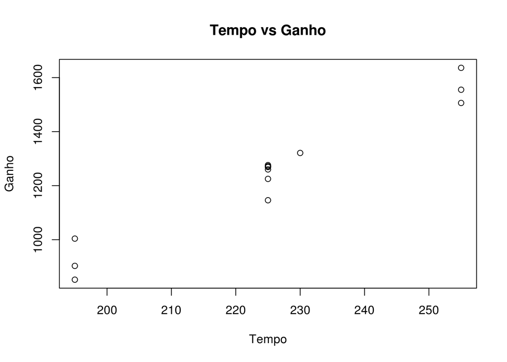

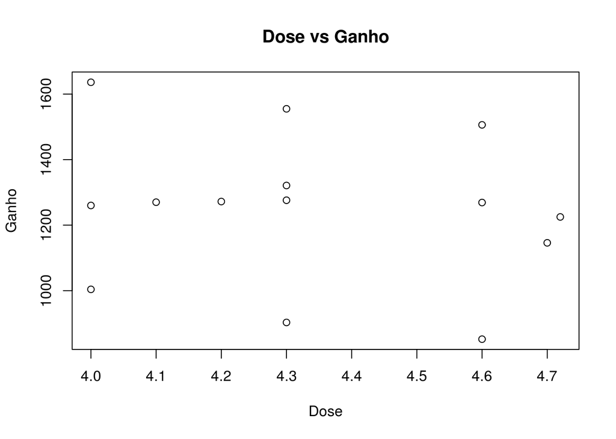

Analisando o gráfico de Tempo vs Ganho, podemos notar que a pouco espalhamento e é possível traçar uma reta que abrange a maioria dos pontos, dando a suspeita que realmente exista uma relação linear entre as variáveis, por outro lado, o gráfico de Dose vs Ganho tem grande espalhamento e indica que não exista uma relação linear.

## Problema B

Realize a análise correlação entre as variáveis envolvidas no estudo, ou seja, estime as correlações lineares entre as variáveis e diga se há suspeita de correlação não nula e, após teste as hipóteses de que cada uma seja nula.

```r
correlacao.a <- cor(dose, ganho)

correlacao.b <- cor(tempo, ganho)
```

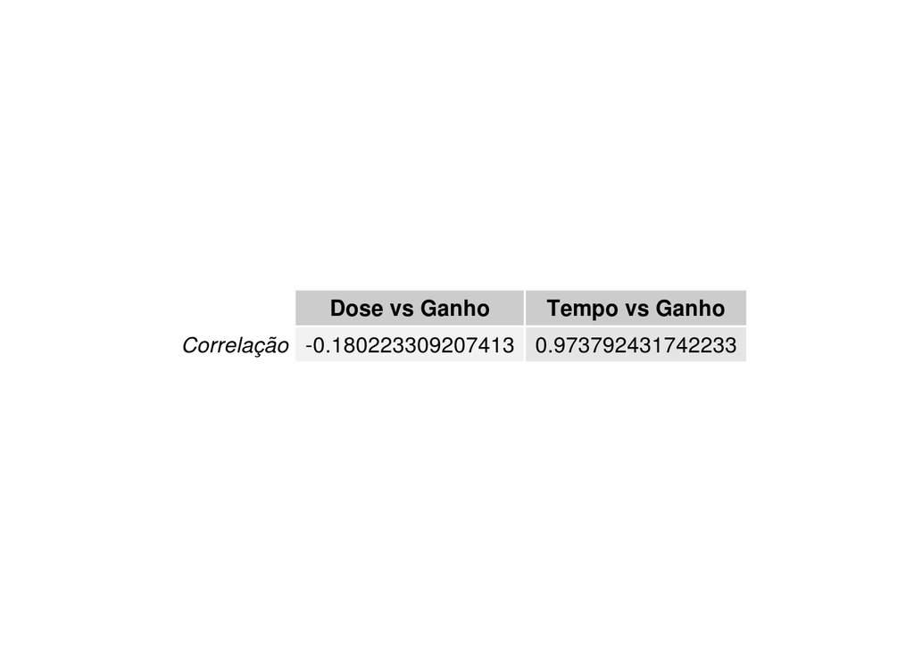

Analisando a tabela acima podemos observar que a correlação dose e ganho é proxima a zero indicando que a pouca correlação entre essas variáveis, já a correlação tempo e ganho é bastante proxima a 1 indicando que existe forte correlacão.

```r
cor.test(tempo,ganho)
```

```
##
##  Pearson's product-moment correlation
##
## data:  tempo and ganho
## t = 14.832, df = 12, p-value = 4.421e-09
## alternative hypothesis: true correlation is not equal to 0
## 95 percent confidence interval:
##  0.9170068 0.9918886
## sample estimates:
##       cor
## 0.9737924
```

```r
cor.test(dose,ganho)
```

```
##
##  Pearson's product-moment correlation
##
## data:  dose and ganho
## t = -0.6347, df = 12, p-value = 0.5375
## alternative hypothesis: true correlation is not equal to 0
## 95 percent confidence interval:
##  -0.6487660  0.3874005
## sample estimates:
##        cor
## -0.1802233
```

## Problema C

Apresente o vetor de estimativas dos coeficientes βˆ.

```r
modelo <- lm(ganho ~ tempo + dose)
coefficients(modelo)
```

```
## (Intercept)       tempo        dose
##  -520.07668    10.78116  -152.14887
```

## Problema D

Apresente o vetor de estimativas dos valores previstos ˆy = Xβˆ.

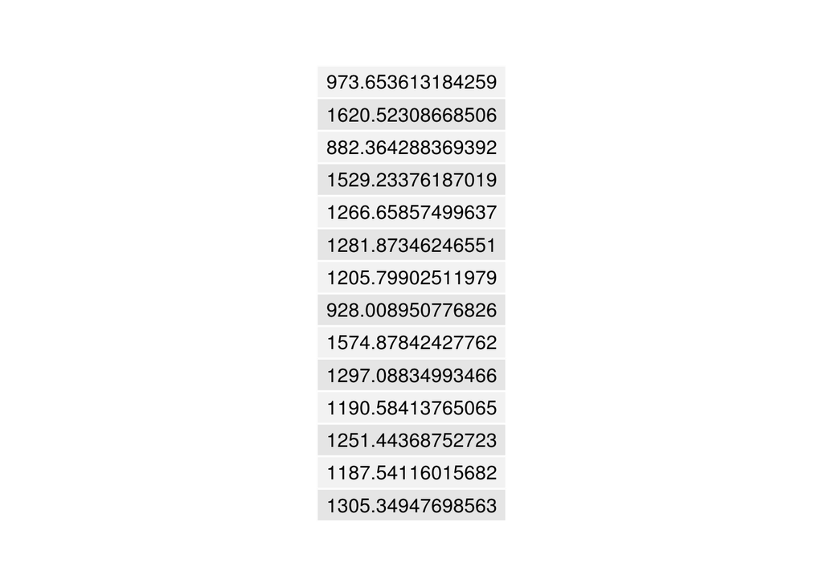

## Problema E

Calcule a Soma de Quadrados Total (SQT otal) e a Soma de Quadrados de Regressão (SQReg) para então calcular o coeficiente de determinação R2 e diga se o modelo de regressão explica bem a variabilidade total dos dados

```r
SQerro <- sum((ganho-predict(modelo))^2)
SQerro
```

```
## [1] 13421.12
```

```r
SQtotal <- sum((ganho-mean(ganho))^2)
SQtotal
```

```
## [1] 665387.2
```

```r
R2 <- 1 - SQerro/SQtotal
R2
```

```
## [1] 0.9798296
```

O modelo consegue explicar aproximadamente 97,9% da variabilidade.

## Problema F

Realize uma ANOVA (Análise de Variância) ao nı́vel de 5% de significância e diga se estatı́sticamente é significativo dizer que pelo menos uma das variáveis independentes exerce influência sobre a variável dependente/resposta y.

```r
amostra.anova <- aov(amostra$y.ganho ~ amostra$x1.tempo + amostra$x2.dose)
summary(amostra.anova)
```

```
##                  Df Sum Sq Mean Sq F value   Pr(>F)
## amostra$x1.tempo  1 630968  630968  517.14 1.34e-10 ***
## amostra$x2.dose   1  20998   20998   17.21  0.00162 **
## Residuals        11  13421    1220
## ---
## Signif. codes:  0 '***' 0.001 '**' 0.01 '*' 0.05 '.' 0.1 ' ' 1
```

Ao observar a tabela ANOVA, as variáveis tempo e dose obteveram valores de Pr(>F), respectivamente, iguais a 1.34e-10 e 0.00162. Logo, quanto menor o valor de Pr mais significativo se torna o teste no sentido de maior evidência estatı́stica existir para se rejeitar a hipótese nula. Sendo assim, concluímos que as duas variáveis exercem influência sobre a variável ganho.

## Problema G

Realize testes marginais (t de Student) para testar individualmente se cada variável independente exerce influência sobre a variável dependente y

```r
t.test(amostra$y.ganho, amostra$x1.tempo, alternative = "two.sided")
```

```
##
##  Welch Two Sample t-test
##
## data:  amostra$y.ganho and amostra$x1.tempo
## t = 16.872, df = 13.212, p-value = 2.533e-10
## alternative hypothesis: true difference in means is not equal to 0
## 95 percent confidence interval:
##   893.342 1155.229
## sample estimates:
## mean of x mean of y
## 1249.6429  225.3571
```

```r
t.test(amostra$y.ganho, amostra$x2.dose, alternative = "two.sided")
```

```
##
##  Welch Two Sample t-test
##
## data:  amostra$y.ganho and amostra$x2.dose
## t = 20.596, df = 13, p-value = 2.622e-11
## alternative hypothesis: true difference in means is not equal to 0
## 95 percent confidence interval:
##  1114.680 1375.932
## sample estimates:
##   mean of x   mean of y
## 1249.642857    4.337143
```

Para um nível de significância 5%, temos que o valor p é menor que alpha, para ambos os testes. Sendo assim, concluímos que a hipótese nula é rejeitada, o que nos mostra que existe relação entre o ganho dos transmissores e as duas variáveis de entrada (Tempo de emissão de íons e Dose de íons)

## Problema H

Diga qual é o ganho estimado se uma observação aleatória tem tempo 255 e e dose de 4.3.

```r
X1 <- 255
X2 <- 4.3
Y <- beta.0 + (beta.1*X1) + (beta.2*X2)
Y
```

```
## (Intercept)
##    1574.878
```

Logo, o ganho estimado é 1574.878.